# Coverage and uptake of neutralising monoclonal antibodies or antivirals for non-hospitalised patients with COVID-19

$$\\[0.25cm]$$

# Overview

While vaccines remain the best strategy to prevent COVID-19, recent evidence suggests monoclonal antibodies (nMABs) or antivirals could potentially benefit certain vulnerable populations before or after exposure to SARS-CoV-2, such as the unvaccinated or recently vaccinated high-risk patients.

With the recent roll out of nMABs and antivirals, there is an urgent need to for knowledge and understanding around the use of nMABs and antivirals in the treatment of patients with COVID-19, such as factors of relevance in determining nMAB and antiviral treatment and the impact of nMAB and antiviral treatment in the community and hospital settings.

The code and data for this report can be found at the OpenSafely [antibody-and-antiviral-deployment repository](https://github.com/opensafely/antibody-and-antiviral-deployment).

##### Contents

- Introduction
- Methods
- Results
  - Coverage of COVID-19 treatment
  - Delivery of nMAB and antiviral treatment
  - Key demographic and clinical characteristics of treated patients
  - Concordance with guidance
  - Time to treatment
  - COVID-19-related events

# Results

## Coverage of COVID-19 treatment

$$\\[0.5cm]$$

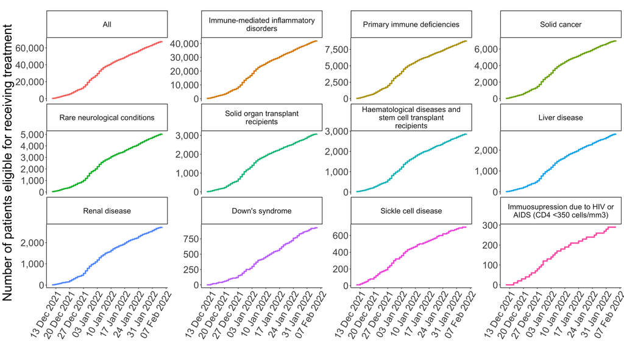

Figure 1: Cumulative total of patients eligible for receiving a nMABs or antiviral for treating COVID-19 since 11th December 2021, stratified by high risk cohort. Note, eligible patients can appear in more than one high risk group and the overall number in each group is likely to be an overestimation due to including patients where their SARS-CoV-2 infection is confirmed by a lateral flow or polymerase chain reaction test.

$$\\[0.5cm]$$

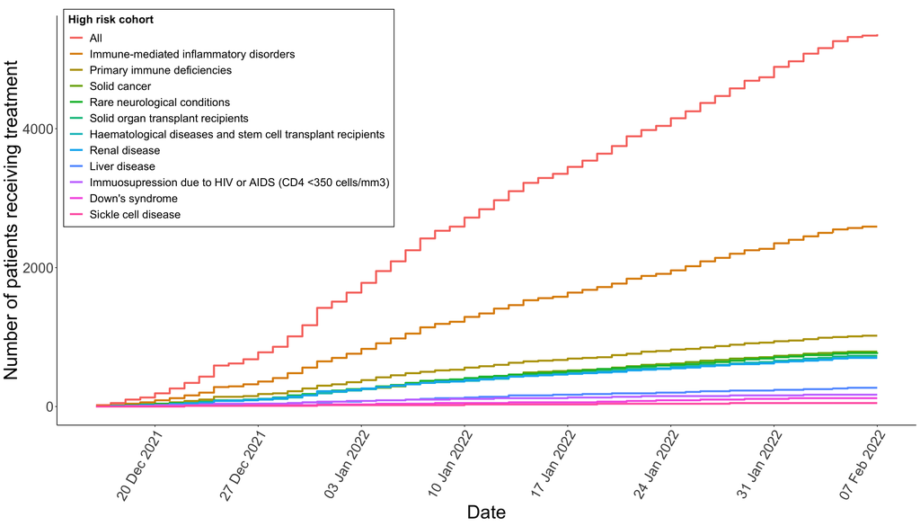

Figure 2: Cumulative total of patients who received a nMABs or antiviral for treating COVID-19 since 11th December 2021, stratified by high risk cohorts. Note, eligible treated patients can appear in more than one high risk group

## Delivery of nMAB and antiviral treatment

Table 1: Proportion of patients receiving treatment for COVID-19, broken down by high risk cohort and treatment type

| High risk cohort | Eligible patients n | Treated Patients All, n | Treated Patients All, % | Treated Patients Sotrovimab, n (%) | Treated Patients Molnupiravir, n (%) | Treated Patients Casirivimab, n (%) |
| --- | --- | --- | --- | --- | --- | --- |
| All | 67640 | 5370 | 8 | 2870 (53) | 2450 (46) | 50 (1) |
| Immune-mediated inflammatory disorders | 42500 | 2600 | 6 | 1390 (53) | 1180 (45) | 20 (1) |
| Primary immune deficiencies | 8870 | 1020 | 11 | 510 (50) | 500 (49) | 10 (1) |
| Solid cancer | 7240 | 790 | 11 | 440 (56) | 340 (43) | 10 (1) |
| Rare neurological conditions | 5070 | 780 | 15 | 390 (50) | 380 (49) | 10 (1) |
| Solid organ transplant recipients | 3100 | 730 | 24 | 440 (60) | 280 (38) | 10 (1) |
| Haematological diseases and stem cell transplant recipients | 2950 | 710 | 24 | 380 (54) | 320 (45) | 10 (1) |
| Liver disease | 2790 | 270 | 10 | 130 (48) | 130 (48) | <5 |
| Renal disease | 2780 | 700 | 25 | 450 (64) | 240 (34) | 10 (1) |
| Down’s syndrome | 950 | 120 | 13 | 40 (33) | 80 (67) | <5 |
| Sickle cell disease | 710 | 50 | 7 | 20 (40) | 30 (60) | <5 |
| Immuosupression due to HIV or AIDS (CD4 <350 cells/mm3) | 300 | 170 | 57 | 70 (41) | 110 (65) | <5 |

## Key demographic and clinical characteristics of treated patients

Table 2 shows the number and proportion of patients who had received treatment by 05-Feb-2022, broken down by demographic and clinical categories and treatment type.

Table 2: Count and proportion of patients who had received treatment for COVID-19, broken down by demographic and clinical categories

Treated

Eligible

All

Sotrovimab

Molnupiravir

Casirivimab

Group

Variable

Count

Count

%

Count

%

Count

%

Count

%

Age band

12-29

9380

460

5

240

52

210

46

10

2

30-39

10560

840

8

470

56

360

43

10

1

40-49

12040

1100

9

600

55

490

45

10

1

50-59

13200

1190

9

650

55

520

44

10

1

60-69

10380

940

9

510

54

420

45

10

1

70-79

7990

630

8

320

51

300

48

<5

<5

80+

4940

220

4

80

36

130

59

<5

<5

Sex

Female

41940

3140

7

1710

54

1400

45

20

1

Male

26560

2230

8

1160

52

1040

47

30

1

Unknown

<5

<5

<5

<5

<5

<5

<5

<5

<5

Ethnicity

White

53780

4530

8

2440

54

2040

45

40

1

Asian or Asian British

3460

280

8

170

61

110

39

<5

<5

Black or Black British

2200

170

8

90

53

80

47

<5

<5

Mixed

860

70

8

40

57

40

57

<5

<5

Other ethnic groups

1040

80

8

30

38

50

63

<5

<5

Unknown

7160

240

3

100

42

130

54

<5

<5

IMD

1 most deprived

15580

780

5

430

55

350

45

10

1

2

13780

1000

7

530

53

460

46

10

1

3

13650

1190

9

630

53

550

46

10

1

4

12450

1110

9

600

54

500

45

10

1

5 least deprived

11060

1130

10

590

52

520

46

10

1

Unknown

1970

160

8

90

56

70

44

<5

<5

Region

East Midlands

12150

840

7

570

68

250

30

20

2

East of England

15650

1740

11

900

52

810

47

20

1

London

3810

350

9

120

34

220

63

<5

<5

North East

3830

290

8

220

76

80

28

<5

<5

North West

8320

520

6

240

46

280

54

<5

<5

South East

3940

330

8

170

52

160

48

<5

<5

South West

7310

750

10

330

44

410

55

<5

<5

West Midlands

2940

210

7

160

76

40

19

<5

<5

Yorkshire and the Humber

10450

340

3

150

44

190

56

<5

<5

Unknown

100

10

10

<5

<5

<5

<5

<5

<5

Clinical group

Autism

410

30

7

10

33

20

67

<5

<5

Care home

1780

50

3

10

20

40

80

<5

<5

Dementia

1330

40

3

10

25

30

75

<5

<5

Learning disability

1230

130

11

50

38

80

62

<5

<5

Serious mental illness

900

50

6

20

40

30

60

<5

<5

Clinically extremely vulnerable

28260

3830

14

2090

55

1700

44

40

1

Vaccination status

Un-vaccinated

5050

130

3

60

46

60

46

<5

<5

One vaccination

2650

110

4

60

55

50

45

<5

<5

Two vaccinations

12860

460

4

240

52

210

46

10

2

Three or more vaccinations

47930

4660

10

2510

54

2120

45

40

1

## Concordance with guidance

Of the 5370 patients who received treatment for COVID-19 between 11-Dec-2021 and 05-Feb-2022, 225 patients were missing records needed to confirm eligibility. It is likely that most, if not all, of these patients meet all of the eligibility criteria and non of the exclusion criteria but, for example, their SARS-CoV-2 test result is not available in their record or we just do not have access to all the criteria the clinician might use to assess high risk group status (such as the patients identified via non digital methods).

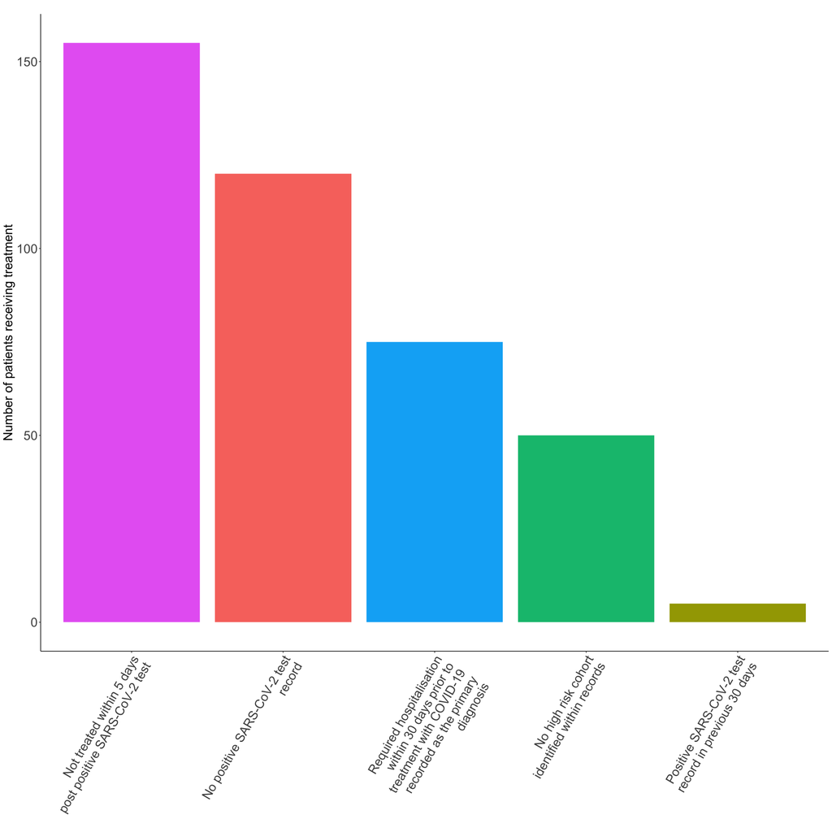

Figure 3: Breakdown of eligibility criteria variables in treated patients with missing records needed to confirm eligibility

## Time to treatment

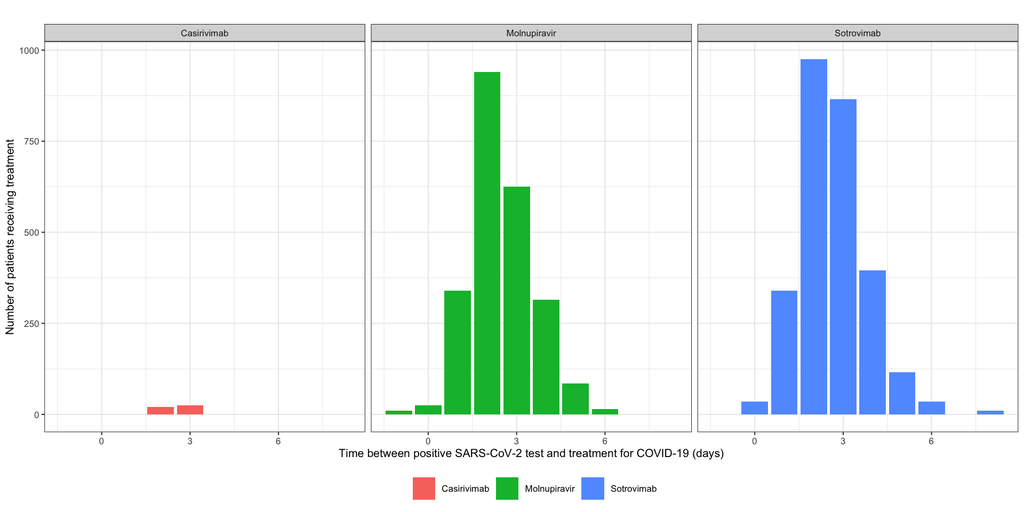

Figure 4a: Time between positive SARS-CoV-2 test and treatment for COVID-19, broken down by treatment type

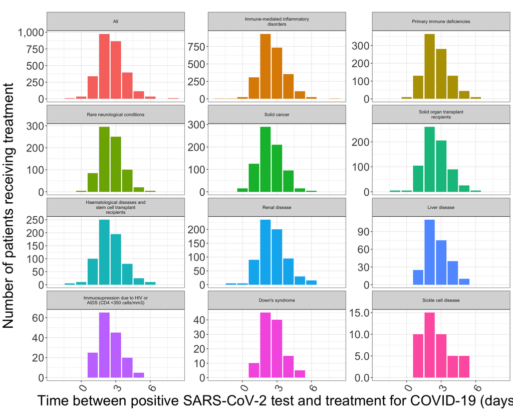

Figure 4b: Time between positive SARS-CoV-2 test and treatment for COVID-19, broken down by high risk cohort

## COVID-19-related events

Table 3: Count and proportion of patients with COVID-19 outcomes. Occurances of hospitalisation and death are included if they occure one day or more after a patient is eligible or recieves treatemnt (start date). Positive SARS-CoV-2 tests are included if they occure 30 days or more since each patients start date.

| Outcome | Un-treated Count | Un-treated % | Treated Count | Treated % |
| --- | --- | --- | --- | --- |
| Positive SARS-CoV-2 test, 30 days or more since start date | 190 | 0.31 | 50 | 0.93 |
| Required hospitalisation with COVID-19 recorded as the primary diagnosis,one or more days after start date | 145 | 0.23 | 95 | 1.77 |
| COVID-19 related death, one or more days after start date | 640 | 1.03 | 15 | 0.28 |